# Análisis Multivariado

- Mostrar todo el código
- Ocultar todo el código
- Ver el código fuente

Unidad III: Análisis de Conglomerados — Práctico

Autores/as

Pablo Ortiz

María Inés Stimolo

Fecha de publicación

23 de septiembre de 2026

# 1 Introducción

El **análisis de conglomerados** (o *clustering*) busca identificar grupos relativamente homogéneos de observaciones a partir de un conjunto de variables: que cada grupo sea internamente homogéneo y heterogéneo respecto de los demás. A diferencia de los métodos de clasificación supervisada, acá no hay una variable de grupo conocida de antemano (por eso, también se lo llama *clasificación no supervisada*).

## 1.1 Los conjuntos de datos

Trabajamos principalmente con `USArrests`, un conjunto que viene incluido en R base: 50 estados de Estados Unidos, con datos de 1973 (*World Almanac*), cuatro variables:

| Variable | Significado |
| --- | --- |
| `Murder` | Arrestos por homicidio cada 100.000 habitantes |
| `Assault` | Arrestos por agresión cada 100.000 habitantes |
| `UrbanPop` | Porcentaje de población urbana |
| `Rape` | Arrestos por violación cada 100.000 habitantes |

Adicionalmente, se itulizará también `penguins` (el de la Unidad 1) para dos cosas que `USArrests` no permite: comparar los conglomerados encontrados contra grupos verdaderamente conocidos (las especies), y trabajar con variables categóricas.

**TipMaterial del práctico**

Todo el código de este documento está disponible como script de R en el repositorio de la materia:

- [Descargar `Unidad3_Cluster.R`](https://raw.githubusercontent.com/pabort/MAE-Multivariado/main/Unidad3_Cluster.R) (clic derecho → “Guardar enlace como…”)
- [Ver el repositorio completo](https://github.com/pabort/MAE-Multivariado)

El script está organizado en las mismas secciones que este documento, así que se puede navegar desde el índice de RStudio (Ctrl+Shift+O).

# 2 Carga de paquetes y datos

**Mostrar código**

```r
for (loc in c("es_AR.UTF-8", "es_ES.UTF-8", "en_US.UTF-8", "C.UTF-8", "C.utf8")) {
  if (Sys.setlocale("LC_CTYPE", loc) != "") break
}

library(cluster)      # dist, daisy, silhouette
library(fpc)           # calinhara
library(clValid)       # comparación de agrupamientos
library(mclust)        # adjustedRandIndex
library(factoextra)    # visualización (fviz_dend, fviz_cluster, fviz_nbclust)
library(tidyverse)      # al final, para que dplyr::select() no quede enmascarado

theme_set(theme_minimal(base_size = 11))
```

**Mostrar código**

```r
data(USArrests)

url_penguins <- "https://raw.githubusercontent.com/allisonhorst/palmerpenguins/main/inst/extdata/penguins.csv"
penguins <- read_csv(url_penguins, show_col_types = FALSE) |>
  drop_na()

dim(USArrests)
```

```
[1] 50  4
```

**Mostrar código**

```r
head(USArrests)
```

|  | Murder | Assault | UrbanPop | Rape |
| --- | --- | --- | --- | --- |
| Alabama | 13.2 | 236 | 58 | 21.2 |
| Alaska | 10.0 | 263 | 48 | 44.5 |
| Arizona | 8.1 | 294 | 80 | 31.0 |
| Arkansas | 8.8 | 190 | 50 | 19.5 |
| California | 9.0 | 276 | 91 | 40.6 |
| Colorado | 7.9 | 204 | 78 | 38.7 |

# 3 Análisis descriptivo por grupos

Antes de tener conglomerados conviene fijar la notación que se va a usar para describirlos, porque es la misma que sostiene a los criterios de selección del número de grupos de la sección Sección 6: todos comparan variabilidad *dentro* de los grupos contra variabilidad *entre* grupos.

Para $G$ grupos, con $\bar{\textbf{x}}_g$ la media del grupo $g$ y $\bar{\textbf{x}}$ la media general, la Suma de Cuadrados y Productos Cruzados **Total** ($\textbf{T}$) se descompone en una parte **Dentro** ($\textbf{W}$, intra-grupos) y una parte **Entre** ($\textbf{B}$, inter-grupos):

$$\textbf{T} = \textbf{W} + \textbf{B}, \qquad \textbf{W} = \textbf{W}_1 + \textbf{W}_2 + \cdots + \textbf{W}_G, \qquad \textbf{B} = \sum_{g=1}^{G} n_g(\bar{\textbf{x}}_g-\bar{\textbf{x}})(\bar{\textbf{x}}_g-\bar{\textbf{x}})'$$

donde $\textbf{W}_g = \sum_{i=1}^{n_g}(\textbf{x}_{ig}-\bar{\textbf{x}}_g)(\textbf{x}_{ig}-\bar{\textbf{x}}_g)'$. La estimación combinada (*pooled*) de la matriz de covarianzas intra-grupos es $\textbf{S}_p = \textbf{W}/(n-G)$.

## 3.1 Un ejemplo con dos grupos conocidos

Para ver la descomposición en acción, conviene un ejemplo donde los grupos ya estén dados. Supongamos 8 empresas hipotéticas con dos variables: inversión publicitaria y ventas (Aldás y Uriel, 2017), divididas en dos grupos intuitivos: $G_1=\{E1,E2,E3,E4\}$ y $G_2=\{E5,E6,E7,E8\}$. Este mismo ejemplo se retoma en la sección de agrupamiento jerárquico.

**Mostrar código**

```r
empresas <- tibble(
  empresa   = paste0("E", 1:8),
  inversion = c(16, 12, 10, 12, 45, 50, 45, 50),
  ventas    = c(10, 14, 22, 25, 10, 15, 25, 27)
) |>
  column_to_rownames("empresa")

grupo_empresas <- factor(rep(1:2, each = 4))

empresas
```

|  | inversion | ventas |
| --- | --- | --- |
| E1 | 16 | 10 |
| E2 | 12 | 14 |
| E3 | 10 | 22 |
| E4 | 12 | 25 |
| E5 | 45 | 10 |
| E6 | 50 | 15 |
| E7 | 45 | 25 |
| E8 | 50 | 27 |

**Mostrar código**

```r
xbar <- colMeans(empresas)
T_mat <- crossprod(as.matrix(sweep(empresas, 2, xbar)))

W_grupo <- function(g) {
  datos_g <- empresas[grupo_empresas == g, ]
  crossprod(as.matrix(sweep(datos_g, 2, colMeans(datos_g))))
}

W_mat <- W_grupo(1) + W_grupo(2)
B_mat <- T_mat - W_mat

list(T = T_mat, W = W_mat, B = B_mat)
```

```
$T
          inversion ventas
inversion      2494     83
ventas           83    346

$W
          inversion ventas
inversion        44  -22.0
ventas          -22  341.5

$B
          inversion ventas
inversion      2450  105.0
ventas          105    4.5
```

Se verifica numéricamente que $\textbf{T} = \textbf{W} + \textbf{B}$, comparando la matriz Total contra la suma de Dentro y Entre:

**Mostrar código**

```r
stopifnot(isTRUE(all.equal(T_mat, W_mat + B_mat)))

round(T_mat, 2)
```

```
          inversion ventas
inversion      2494     83
ventas           83    346
```

**Mostrar código**

```r
round(W_mat + B_mat, 2)
```

```
          inversion ventas
inversion      2494     83
ventas           83    346
```

Con $\textbf{W}$ ya calculada, la matriz *pooled* $\textbf{S}_p = \textbf{W}/(n-G)$ es la estimación combinada de la covarianza intra-grupos, la que se usa cuando conviene resumir en una sola matriz la dispersión dentro de ambos grupos:

**Mostrar código**

```r
n_empresas <- nrow(empresas)
G_empresas <- nlevels(grupo_empresas)

Sp_mat <- W_mat / (n_empresas - G_empresas)
Sp_mat
```

```
          inversion    ventas
inversion  7.333333 -3.666667
ventas    -3.666667 56.916667
```

# 4 Medidas de proximidad

Toda técnica de agrupamiento necesita una noción de qué tan parecidas o distintas son dos observaciones. Esta sección recorre las medidas más usuales y muestra cómo se calculan en R.

Sean $r$ y $s$ dos observaciones cualesquiera (de las $n$ posibles), y $x_{rj}$, $x_{sj}$ los valores que toman en la variable $x_j$ ($j=1,\dots,p$).

## 4.1 Variables métricas

**Mostrar código**

```r
# Trabajamos con las 4 primeras filas de USArrests, alcanza para comparar medidas
sub_arrests <- USArrests[1:4, ]
sub_arrests
```

|  | Murder | Assault | UrbanPop | Rape |
| --- | --- | --- | --- | --- |
| Alabama | 13.2 | 236 | 58 | 21.2 |
| Alaska | 10.0 | 263 | 48 | 44.5 |
| Arizona | 8.1 | 294 | 80 | 31.0 |
| Arkansas | 8.8 | 190 | 50 | 19.5 |

**Distancia euclídea** y su versión al cuadrado:

$$d_{rs} = \sqrt{\sum_{j=1}^{p} (x_{rj}-x_{sj})^2} \qquad\qquad d_{rs}^2 = \sum_{j=1}^{p} (x_{rj}-x_{sj})^2$$

**Mostrar código**

```r
dist(sub_arrests, method = "euclidean")
```

```
           Alabama    Alaska   Arizona
Alaska    37.17701
Arizona   63.00833  46.59249
Arkansas  46.92814  77.19741 108.85192
```

**Mostrar código**

```r
dist(sub_arrests, method = "euclidean")^2   # al cuadrado: evita la raíz, más liviana de calcular
```

```
          Alabama   Alaska  Arizona
Alaska    1382.13
Arizona   3970.05  2170.86
Arkansas  2202.25  5959.44 11848.74
```

**Distancia Manhattan** (o *city block*): suma de diferencias absolutas, en vez de la suma de cuadrados.

$$d_{rs} = \sum_{j=1}^{p} |x_{rj}-x_{sj}|$$

**Mostrar código**

```r
dist(sub_arrests, method = "manhattan")
```

```
         Alabama Alaska Arizona
Alaska      63.5
Arizona     94.9   78.4
Arkansas    60.1  101.2   146.2
```

Ambas son casos particulares de la **distancia de Minkowski**:

$$d_{rs}^{(k)} = \left(\sum_{j=1}^{p} |x_{rj}-x_{sj}|^{k}\right)^{1/k}$$

con $k=1$ la Manhattan y $k=2$ la euclídea. Cuando $k\to\infty$, se obtiene la **distancia de Tchebycheff**, que se queda solo con la mayor diferencia entre las variables:

$$\lim_{k\to\infty} d_{rs}^{(k)} = \max\{|x_{r1}-x_{s1}|,\dots,|x_{rp}-x_{sp}|\}$$

**Mostrar código**

```r
d_chebyshev <- dist(sub_arrests, method = "maximum")

# La distancia de Minkowski se acerca a la de Tchebycheff a medida que k crece
# (no llega a converger exactamente por el límite de precisión numérica con exponentes grandes)
tibble(
  k = c(1, 2, 10, 50, 100),
  diferencia_maxima_vs_chebyshev = map_dbl(k, \(k) max(abs(dist(sub_arrests, method = "minkowski", p = k) - d_chebyshev)))
)
```

| k | diferencia_maxima_vs_chebyshev |
| --- | --- |
| 1 | 46.40000000 |
| 2 | 14.59248867 |
| 10 | 1.79934164 |
| 50 | 0.11927615 |
| 100 | 0.01310654 |

**Mostrar código**

```r
d_chebyshev
```

```
         Alabama Alaska Arizona
Alaska        27
Arizona       58     32
Arkansas      46     73     104
```

**Distancias invariantes a cambios de escala.** Las anteriores cambian si se multiplica una variable por una constante; estas no:

- **Canberra** (una Manhattan “relativizada” por la magnitud de cada observación):
  $$d_{rs} = \sum_{j=1}^{p} \frac{|x_{rj}-x_{sj}|}{|x_{rj}|+|x_{sj}|}$$
- **Karl Pearson** (una euclídea relativizada por la varianza de cada variable, $s_{jj}$):
  $$d_{rs} = \sqrt{\sum_{j=1}^{p} \frac{(x_{rj}-x_{sj})^2}{s_{jj}}}$$
- **Mahalanobis** (tiene en cuenta también las correlaciones entre variables, a través de $S^{-1}$):
  $$d_{rs} = \sqrt{(\textbf{x}_r-\textbf{x}_s)' S^{-1} (\textbf{x}_r-\textbf{x}_s)}$$

**Mostrar código**

```r
dist(sub_arrests, method = "canberra")
```

```
           Alabama    Alaska   Arizona
Alaska   0.6410212
Arizona  0.6960303 0.5894356
Arkansas 0.4238243 0.6360109 0.7147882
```

**Mostrar código**

```r
# Karl Pearson: R no la trae armada. Se ve en la fórmula que equivale a una euclídea
# sobre las variables ponderadas por 1/sqrt(s_jj), así que se arma reescalando primero
s_jj <- diag(var(USArrests))
sub_pearson <- sweep(sub_arrests, 2, sqrt(s_jj), FUN = "/")
dist(sub_pearson, method = "euclidean")
```

```
          Alabama   Alaska  Arizona
Alaska   2.703754
Arizona  2.293520 2.700643
Arkansas 1.289810 2.826039 2.717758
```

**Mostrar código**

```r
# Mahalanobis: tampoco está en dist(), pero S^-1 = L'L (descomposición de Cholesky),
# así que es la distancia euclídea de siempre sobre los datos transformados por L
S    <- cov(USArrests)
L    <- chol(solve(S))
d_maha <- dist(as.matrix(sub_arrests) %*% t(L))
round(as.matrix(d_maha), 3)
```

```
         Alabama Alaska Arizona Arkansas
Alabama    0.000  4.397   3.157    1.418
Alaska     4.397  0.000   3.874    3.506
Arizona    3.157  3.874   0.000    2.700
Arkansas   1.418  3.506   2.700    0.000
```

Es la misma idea que la estandarización multivariante de la Unidad 1: esferizar los datos (llevar la covarianza a la identidad) y medir después la distancia euclídea de siempre. Ahí se usaba la raíz cuadrada simétrica $S^{-1/2}=U\Lambda^{-1/2}U'$, obtenida por descomposición espectral; acá alcanza con cualquier matriz $L$ que cumpla $S^{-1}=L'L$, y la descomposición de Cholesky da una directamente, sin pasar por autovalores.

Vale aclarar la diferencia con `stats::mahalanobis()`: esa función calcula la distancia de cada observación a un punto fijo (típicamente la media), no la distancia entre pares de observaciones. Es la que se usa en la Unidad 1 para detectar observaciones atípicas multivariadas.

**NotaVerificación: la distancia de Mahalanobis vía Cholesky coincide con la forma cuadrática**

**Mostrar código**

```r
Sinv <- solve(S)
maha_forma_cuadratica <- function(r, s) sqrt(t(r - s) %*% Sinv %*% (r - s))

pares <- combn(1:4, 2)
maha_manual <- apply(pares, 2, \(idx) {
  maha_forma_cuadratica(as.numeric(sub_arrests[idx[1], ]), as.numeric(sub_arrests[idx[2], ]))
})
maha_cholesky <- as.matrix(d_maha)[t(pares)]

stopifnot(isTRUE(all.equal(as.numeric(maha_manual), as.numeric(maha_cholesky))))

round(maha_manual, 3)
```

```
[1] 4.397 3.157 1.418 3.874 3.506 2.700
```

**Mostrar código**

```r
round(maha_cholesky, 3)
```

```
[1] 4.397 3.157 1.418 3.874 3.506 2.700
```

**NotaCómo guarda R las distancias: `dist` vs. `as.matrix()`**

`dist()` no devuelve una matriz: devuelve un objeto de clase `dist`, que almacena solo el triángulo inferior de la matriz de distancias, sin la diagonal. No hace falta guardar más que eso: la matriz es simétrica ($d_{rs}=d_{sr}$) y la diagonal es siempre cero ($d_{rr}=0$).

Esto tiene una consecuencia visible al imprimir. Con las 8 empresas de la sección anterior:

**Mostrar código**

```r
d_empresas <- dist(empresas)
d_empresas
```

```
          E1        E2        E3        E4        E5        E6        E7
E2  5.656854
E3 13.416408  8.246211
E4 15.524175 11.000000  3.605551
E5 29.000000 33.241540 37.000000 36.249138
E6 34.365681 38.013156 40.607881 39.293765  7.071068
E7 32.649655 34.785054 35.128336 33.000000 15.000000 11.180340
E8 38.013156 40.162171 40.311289 38.052595 17.720045 12.000000  5.385165
```

La primera empresa (E1) no aparece como fila, ni la última (E8) como columna: como ninguna tiene nada nuevo que aportar por encima de la diagonal (E1 ya está cubierta por las distancias de las demás hacia ella, y E8 no tiene ninguna fila debajo), parece que faltan datos, pero es solo la forma compacta de almacenamiento. `as.matrix()` reconstruye la matriz completa, con las 8 filas y columnas y la diagonal en cero:

**Mostrar código**

```r
round(as.matrix(d_empresas), 1)
```

```
     E1   E2   E3   E4   E5   E6   E7   E8
E1  0.0  5.7 13.4 15.5 29.0 34.4 32.6 38.0
E2  5.7  0.0  8.2 11.0 33.2 38.0 34.8 40.2
E3 13.4  8.2  0.0  3.6 37.0 40.6 35.1 40.3
E4 15.5 11.0  3.6  0.0 36.2 39.3 33.0 38.1
E5 29.0 33.2 37.0 36.2  0.0  7.1 15.0 17.7
E6 34.4 38.0 40.6 39.3  7.1  0.0 11.2 12.0
E7 32.6 34.8 35.1 33.0 15.0 11.2  0.0  5.4
E8 38.0 40.2 40.3 38.1 17.7 12.0  5.4  0.0
```

Esto importa para código que busca el par más próximo programáticamente: sobre la matriz completa, `which.min()` va a encontrar siempre la diagonal (todos los ceros) en vez del par más cercano. Hay que excluirla primero:

**Mostrar código**

```r
m_empresas <- as.matrix(d_empresas)
diag(m_empresas) <- Inf

idx_min <- which(m_empresas == min(m_empresas), arr.ind = TRUE)[1, ]
rownames(m_empresas)[idx_min]
```

```
[1] "E4" "E3"
```

**NotaVerificación: la distancia de Canberra manual coincide con `dist()`**

**Mostrar código**

```r
r <- as.numeric(sub_arrests[1, ])
s <- as.numeric(sub_arrests[2, ])

canberra_manual <- sum(abs(r - s) / (abs(r) + abs(s)))
canberra_dist    <- as.matrix(dist(sub_arrests, method = "canberra"))[1, 2]

stopifnot(isTRUE(all.equal(canberra_manual, canberra_dist)))

c(manual = canberra_manual, dist = canberra_dist)
```

```
   manual      dist
0.6410212 0.6410212
```

## 4.2 Variables dicotómicas

Cuando las variables son de presencia/ausencia, la comparación entre dos observaciones $r$ y $s$ medidas sobre $p$ atributos binarios se resume en una tabla de coincidencias:

|  | $s$: Presencia | $s$: Ausencia |
| --- | --- | --- |
| **$r$: Presencia** | $a$ | $b$ |
| **$r$: Ausencia** | $c$ | $d$ |

$a$ es la cantidad de atributos presentes en ambas observaciones, $b$ los presentes solo en $r$, $c$ los presentes solo en $s$, y $d$ los ausentes en ambas, con $a+b+c+d=p$. Con las letras ya definidas, conviene verlas en un ejemplo concreto antes de pasar a las fórmulas de similaridad.

### 4.2.1 Comparando pares de observaciones

Usamos seis pingüinos, uno por cada combinación de especie y sexo, y cuatro atributos binarios: si es macho, si la isla es Biscoe, si el largo de aleta supera la mediana del conjunto completo, y si la masa corporal supera esa mediana.

**Mostrar código**

```r
med_flipper <- median(penguins$flipper_length_mm)
med_masa    <- median(penguins$body_mass_g)

bin_penguins <- penguins |>
  group_by(species, sex) |>
  slice(1) |>
  ungroup() |>
  arrange(species, desc(sex)) |>
  transmute(
    pinguino    = paste0(str_sub(species, 1, 3), "_", if_else(sex == "male", "m", "h")),
    macho       = as.integer(sex == "male"),
    isla_biscoe = as.integer(island == "Biscoe"),
    aleta_larga = as.integer(flipper_length_mm > med_flipper),
    pesado      = as.integer(body_mass_g > med_masa)
  ) |>
  column_to_rownames("pinguino")

bin_penguins
```

|  | macho | isla_biscoe | aleta_larga | pesado |
| --- | --- | --- | --- | --- |
| Ade_m | 1 | 0 | 0 | 0 |
| Ade_h | 0 | 0 | 0 | 0 |
| Chi_m | 1 | 0 | 0 | 0 |
| Chi_h | 0 | 0 | 0 | 0 |
| Gen_m | 1 | 1 | 1 | 1 |
| Gen_h | 0 | 1 | 1 | 1 |

Para comparar dos pingüinos alcanza con recorrer sus cuatro atributos y anotar en qué celda de la tabla de coincidencias cae cada uno. Se escribe **una función**, para no repetir el bloque por cada par:

**Mostrar código**

```r
comparar_binario <- function(datos, obs1, obs2) {
  detalle <- tibble(
    atributo = colnames(datos),
    !!obs1   := as.numeric(datos[obs1, ]),
    !!obs2   := as.numeric(datos[obs2, ])
  ) |>
    mutate(celda = case_when(
      .data[[obs1]] == 1 & .data[[obs2]] == 1 ~ "a",
      .data[[obs1]] == 1 & .data[[obs2]] == 0 ~ "b",
      .data[[obs1]] == 0 & .data[[obs2]] == 1 ~ "c",
      .data[[obs1]] == 0 & .data[[obs2]] == 0 ~ "d"
    ))

  abcd <- table(factor(detalle$celda, levels = c("a", "b", "c", "d")))

  tabla2x2 <- matrix(
    abcd[c("a", "b", "c", "d")], nrow = 2, byrow = TRUE,
    dimnames = list(paste0(obs1, ": ", c("Presencia", "Ausencia")),
                    paste0(obs2, ": ", c("Presencia", "Ausencia")))
  )

  list(detalle = detalle, tabla2x2 = tabla2x2, abcd = abcd)
}
```

El primer par, un macho y una hembra de la misma especie:

**Mostrar código**

```r
par_gentoo <- comparar_binario(bin_penguins, "Gen_m", "Gen_h")
par_gentoo$detalle
```

| atributo | Gen_m | Gen_h | celda |
| --- | --- | --- | --- |
| macho | 1 | 0 | b |
| isla_biscoe | 1 | 1 | a |
| aleta_larga | 1 | 1 | a |
| pesado | 1 | 1 | a |

Contando cuántos atributos caen en cada celda de esa columna se arma la tabla 2×2:

**Mostrar código**

```r
par_gentoo$tabla2x2
```

```
                 Gen_h: Presencia Gen_h: Ausencia
Gen_m: Presencia                3               1
Gen_m: Ausencia                 0               0
```

**Mostrar código**

```r
par_gentoo$abcd
```

```
a b c d
3 1 0 0
```

$a=3$: comparten isla, largo de aleta y masa. $b=1$: difieren en el sexo, presente en Gen_m y ausente en Gen_h. No hay ningún atributo presente solo en Gen_h ($c=0$) ni ausente en ambos ($d=0$).

El segundo par, un macho Adelie y una hembra Chinstrap:

**Mostrar código**

```r
par_ade_chi <- comparar_binario(bin_penguins, "Ade_m", "Chi_h")
par_ade_chi$detalle
```

| atributo | Ade_m | Chi_h | celda |
| --- | --- | --- | --- |
| macho | 1 | 0 | b |
| isla_biscoe | 0 | 0 | d |
| aleta_larga | 0 | 0 | d |
| pesado | 0 | 0 | d |

**Mostrar código**

```r
par_ade_chi$tabla2x2
```

```
                 Chi_h: Presencia Chi_h: Ausencia
Ade_m: Presencia                0               1
Ade_m: Ausencia                 0               3
```

**Mostrar código**

```r
par_ade_chi$abcd
```

```
a b c d
0 1 0 3
```

Acá el reparto es distinto: $a=0$, no comparten ningún atributo presente. $b=1$: Ade_m es macho y Chi_h no. Los otros tres atributos (isla, aleta, masa) están ausentes en ambos, así que $d=3$.

### 4.2.2 Los coeficientes

Con $a$, $b$, $c$ y $d$ ya definidos sobre un ejemplo concreto, los coeficientes de **similaridad** más usuales (a mayor valor, más parecidas) son:

$$\text{Jaccard: } c(r,s)=\frac{a}{a+b+c} \qquad \text{Sokal y Michener: } c(r,s)=\frac{a+d}{a+b+c+d} \qquad \text{Sorensen: } c(r,s)=\frac{2a}{2a+b+c}$$

$d$ no aparece ni en Jaccard ni en Sorensen: ambos ignoran las coincidencias en la ausencia. Sokal y Michener sí las cuenta como parecido, en pie de igualdad con las coincidencias en presencia ($a$).

**Mostrar código**

```r
coeficientes_binarios <- function(abcd) {
  with(as.list(abcd), c(
    a = a, b = b, c = c, d = d,
    jaccard        = a / (a + b + c),
    sokal_michener = (a + d) / (a + b + c + d),
    sorensen       = (2 * a) / (2 * a + b + c)
  ))
}

bind_rows(
  "Gentoo macho vs. Gentoo hembra"    = coeficientes_binarios(par_gentoo$abcd),
  "Adelie macho vs. Chinstrap hembra" = coeficientes_binarios(par_ade_chi$abcd),
  .id = "par"
) |>
  mutate(across(c(jaccard, sokal_michener, sorensen), \(x) round(x, 3)))
```

| par | a | b | c | d | jaccard | sokal_michener | sorensen |
| --- | --- | --- | --- | --- | --- | --- | --- |
| Gentoo macho vs. Gentoo hembra | 3 | 1 | 0 | 0 | 0.75 | 0.75 | 0.857 |
| Adelie macho vs. Chinstrap hembra | 0 | 1 | 0 | 3 | 0.00 | 0.75 | 0.000 |

El segundo par es el que enseña algo: el mismo par de pingüinos tiene una similaridad de 0 o de 0.75 según qué coeficiente se use. En la tabla atributo por atributo de más arriba se ve por qué: las tres coincidencias entre Ade_m y Chi_h son en ausencia (ninguno vive en Biscoe, ninguno tiene aleta larga, ninguno es pesado). Jaccard y Sorensen no cuentan eso como parecido; Sokal y Michener sí, y por eso el mismo par pasa de no tener nada en común a tener 75% de similaridad.

### 4.2.3 Cuál usar

La elección depende de si el atributo es **simétrico** o **asimétrico**. Con atributos simétricos, como `macho`, donde ni la presencia ni la ausencia es más informativa que la otra, conviene Sokal y Michener: no hay razón para tratar una coincidencia en la ausencia como menos relevante que una en la presencia. Con atributos asimétricos, una característica poco frecuente donde el 1 informa y el 0 solo dice “no tiene esto en particular”, conviene Jaccard o Sorensen: si se contaran las ausencias conjuntas como parecido, dos observaciones que no comparten prácticamente ningún atributo raro terminarían pareciendo similares por el solo hecho de no tener nada, y eso infla artificialmente la similaridad entre observaciones que en realidad no tienen mucho en común.

**NotaR ya trae Jaccard armado**

`dist(..., method = "binary")` calcula directamente $1-\text{Jaccard}$ entre todas las observaciones, sin llamar a `comparar_binario()` par por par. Se verifica contra los dos pares ya calculados a mano:

**Mostrar código**

```r
dist_binaria <- dist(bin_penguins, method = "binary")

stopifnot(isTRUE(all.equal(
  c(1 - coeficientes_binarios(par_gentoo$abcd)[["jaccard"]],
    1 - coeficientes_binarios(par_ade_chi$abcd)[["jaccard"]]),
  c(as.matrix(dist_binaria)["Gen_m", "Gen_h"],
    as.matrix(dist_binaria)["Ade_m", "Chi_h"])
)))

round(as.matrix(dist_binaria), 2)
```

```
      Ade_m Ade_h Chi_m Chi_h Gen_m Gen_h
Ade_m  0.00     1  0.00     1  0.75  1.00
Ade_h  1.00     0  1.00     0  1.00  1.00
Chi_m  0.00     1  0.00     1  0.75  1.00
Chi_h  1.00     0  1.00     0  1.00  1.00
Gen_m  0.75     1  0.75     1  0.00  0.25
Gen_h  1.00     1  1.00     1  0.25  0.00
```

Cualquier similaridad $c(r,s)$ (no solo Jaccard) puede transformarse en una distancia al cuadrado con:

$$d^2_{(r,s)} = c(r,r) + c(s,s) - 2c(r,s)$$

que en notación matricial es $\textbf{D}^2 = 2(\mathbf{1}\mathbf{1}' - \textbf{S})$, con $\textbf{S}$ la matriz de similaridades. Como toda similaridad cumple $c(r,r)=c(s,s)=1$, la fórmula se simplifica a $d^2_{(r,s)} = 2(1-c(r,s))$:

**Mostrar código**

```r
S_binaria       <- 1 - as.matrix(dist_binaria)
D2_transformado <- 2 * (1 - S_binaria)

stopifnot(isTRUE(all.equal(D2_transformado, 2 * as.matrix(dist_binaria))))

round(D2_transformado, 3)
```

```
      Ade_m Ade_h Chi_m Chi_h Gen_m Gen_h
Ade_m   0.0     2   0.0     2   1.5   2.0
Ade_h   2.0     0   2.0     0   2.0   2.0
Chi_m   0.0     2   0.0     2   1.5   2.0
Chi_h   2.0     0   2.0     0   2.0   2.0
Gen_m   1.5     2   1.5     2   0.0   0.5
Gen_h   2.0     2   2.0     2   0.5   0.0
```

Con Jaccard, $D^2$ resulta ser exactamente el doble de $1-\text{Jaccard}$: al ser $c(r,r)=c(s,s)=1$ para cualquier similaridad, $d^2_{(r,s)}=2(1-c(r,s))$ es siempre un múltiplo constante de la distancia $1-c(r,s)$, así que el orden entre pares no cambia entre una y otra. La razón para usar $D^2$ en vez de $1-c(r,s)$ directamente no es corregir una distorsión, sino que $D^2$ es la forma que necesita el escalado multidimensional clásico (Unidad 2b): a partir de una matriz de distancias al cuadrado como esta se puede aplicar directamente el doble centrado $\textbf{Q}=-\tfrac12\textbf{P}\textbf{D}^2\textbf{P}$ para obtener una representación en pocas dimensiones.

## 4.3 Distancia de Gower para datos mixtos

Cuando hay variables cuantitativas y categóricas a la vez (como en `penguins`, con dos numéricas y dos categóricas), ninguna de las distancias anteriores sirve por sí sola. La distancia de Gower combina, para cada variable, una contribución adecuada a su tipo (diferencia normalizada por el rango para las cuantitativas, coincidencia simple para las categóricas) y promedia:

$$d_{rs}^2 = 1 - s_{rs}, \qquad s_{rs} = \frac{\sum_{j=1}^{p_1}\left(1-\frac{|x_{rj}-x_{sj}|}{\text{recorrido}(x_j)}\right) + a + \alpha}{p_1+(p_2-d)+p_3}$$

**Mostrar código**

```r
mix_penguins <- penguins |>
  transmute(bill_length_mm, bill_depth_mm,
            island = factor(island), sex = factor(sex)) |>
  slice(1:6)

mix_penguins
```

| bill_length_mm | bill_depth_mm | island | sex |
| --- | --- | --- | --- |
| 39.1 | 18.7 | Torgersen | male |
| 39.5 | 17.4 | Torgersen | female |
| 40.3 | 18.0 | Torgersen | female |
| 36.7 | 19.3 | Torgersen | female |
| 39.3 | 20.6 | Torgersen | male |
| 38.9 | 17.8 | Torgersen | female |

**Mostrar código**

```r
daisy(mix_penguins, metric = "gower")
```

```
Dissimilarities :
           1          2          3          4          5
2 0.37934028
3 0.38802083 0.10243056
4 0.46354167 0.34288194 0.35156250
5 0.16232639 0.51388889 0.52256944 0.53211806
6 0.33420139 0.07291667 0.11284722 0.26996528 0.49652778

Metric :  mixed ;  Types = I, I, N, N
Number of objects : 6
```

## 4.4 Estandarización

Como se vio recién, las variables cuantitativas entran en las distancias según su escala: una variable con mayor varianza domina el cálculo. Tres formas usuales de estandarizar la observación $x_{rj}$ de la variable $j$:

$$\text{Puntuaciones } Z: \; z_{rj} = \frac{x_{rj}-\bar{x}_j}{\sqrt{s_{jj}}} \qquad \text{Rango 1: } \; z_{rj} = \frac{x_{rj}}{\max(x_j)-\min(x_j)} \qquad \text{Rango } [0,1]: \; z_{rj} = \frac{x_{rj}-\min(x_j)}{\max(x_j)-\min(x_j)}$$

**Mostrar código**

```r
rango1   <- \(x) x / (max(x) - min(x))
rango01  <- \(x) (x - min(x)) / (max(x) - min(x))

USArrests |>
  mutate(across(everything(), list(z = scale, rango1 = rango1, rango01 = rango01))) |>
  select(starts_with("Murder")) |>
  head(4)
```

|  | Murder | Murder_z | Murder_rango1 | Murder_rango01 |
| --- | --- | --- | --- | --- |
| Alabama | 13.2 | 1.24256408 | 0.7951807 | 0.7469880 |
| Alaska | 10.0 | 0.50786248 | 0.6024096 | 0.5542169 |
| Arizona | 8.1 | 0.07163341 | 0.4879518 | 0.4397590 |
| Arkansas | 8.8 | 0.23234938 | 0.5301205 | 0.4819277 |

La sección siguiente retoma esto: la estandarización de tipo $Z$ es la que se usa en la práctica, y cambia el resultado del agrupamiento sobre `USArrests` de forma apreciable.

# 5 Agrupamiento jerárquico

Los métodos jerárquicos construyen una secuencia de particiones $C_0, \dots, C_m$, con $C_0$ formada por $n$ grupos (cada observación es su propio grupo) y $C_m$ por uno solo (todas las observaciones juntas). En cada paso se fusionan los dos grupos más próximos, según algún criterio de distancia entre grupos: el que distingue a los distintos métodos de enlace.

## 5.1 Paso a paso: el método del centroide

Antes de usar `hclust()` conviene reproducir a mano el método, para ver qué hace el algoritmo en cada paso. Son las mismas 8 empresas de la sección anterior, ahora sin conocer los grupos de antemano.

**Paso 1.** Se parte de la matriz de distancias euclídeas al cuadrado entre las 8 empresas:

**Mostrar código**

```r
d2_empresas <- dist(empresas)^2
round(as.matrix(d2_empresas))
```

```
     E1   E2   E3   E4   E5   E6   E7   E8
E1    0   32  180  241  841 1181 1066 1445
E2   32    0   68  121 1105 1445 1210 1613
E3  180   68    0   13 1369 1649 1234 1625
E4  241  121   13    0 1314 1544 1089 1448
E5  841 1105 1369 1314    0   50  225  314
E6 1181 1445 1649 1544   50    0  125  144
E7 1066 1210 1234 1089  225  125    0   29
E8 1445 1613 1625 1448  314  144   29    0
```

El mínimo de la matriz es $d^2(E3,E4)=13$, así que E3 y E4 se fusionan primero. El centroide del nuevo grupo es el promedio de sus dos observaciones:

$$\bar{x}_{1(34)} = \frac{10+12}{2} = 11 \qquad \bar{x}_{2(34)} = \frac{22+25}{2} = 23{,}5$$

**Mostrar código**

```r
centroide_e34 <- colMeans(empresas[c("E3", "E4"), ])
centroide_e34
```

```
inversion    ventas
     11.0      23.5
```

El proceso se repite: se recalcula la matriz de distancias reemplazando E3 y E4 por su centroide, se busca el nuevo mínimo, se fusiona, y así hasta llegar a un solo grupo. `hclust(method = "centroid")` hace exactamente esto:

**Mostrar código**

```r
hc_centroide <- hclust(d2_empresas, method = "centroid")

# Historial de conglomeración: en qué distancia (height) se unió cada par
tibble(paso = seq_along(hc_centroide$height),
       height = hc_centroide$height,
       fusiona_1 = hc_centroide$merge[, 1],
       fusiona_2 = hc_centroide$merge[, 2])
```

| paso | height | fusiona_1 | fusiona_2 |
| --- | --- | --- | --- |
| 1 | 13.00 | -3 | -4 |
| 2 | 29.00 | -7 | -8 |
| 3 | 32.00 | -1 | -2 |
| 4 | 50.00 | -5 | -6 |
| 5 | 141.25 | 1 | 3 |
| 6 | 182.25 | 2 | 4 |
| 7 | 1227.25 | 5 | 6 |

**Mostrar código**

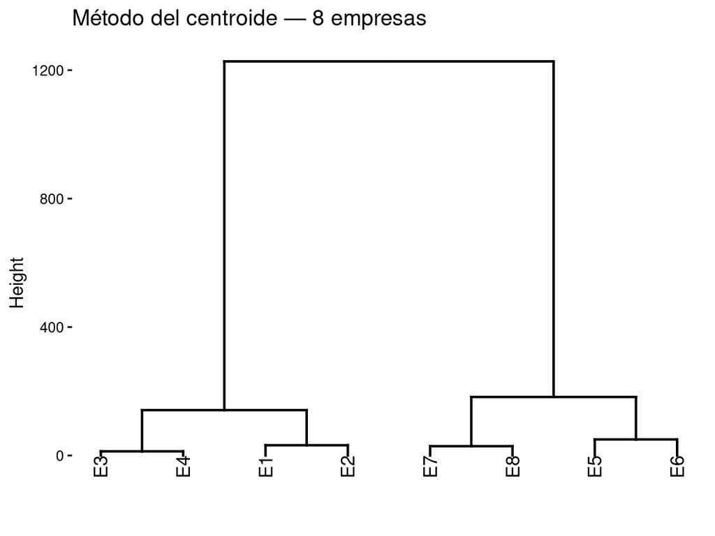

```r
fviz_dend(hc_centroide, main = "Método del centroide — 8 empresas")
```

**NotaVerificación: los primeros pasos de `hclust()` coinciden con el cálculo manual**

**Mostrar código**

```r
# Paso 1: fusiona las observaciones -3 y -4 (E3, E4), a distancia 13
stopifnot(
  identical(hc_centroide$merge[1, ], c(-3L, -4L)),
  isTRUE(all.equal(hc_centroide$height[1], 13))
)

# Paso 5: fusiona el grupo del paso 1 (E34) con el grupo del paso 3 (E12) --
# hclust() codifica esa referencia como merge = c(1, 3). La distancia en ese
# paso debe coincidir con la distancia al cuadrado entre los centroides ya
# recalculados de ambos grupos.
centroide_e12 <- colMeans(empresas[c("E1", "E2"), ])
d2_e34_e12    <- sum((centroide_e34 - centroide_e12)^2)

stopifnot(
  identical(hc_centroide$merge[5, ], c(1L, 3L)),
  isTRUE(all.equal(d2_e34_e12, hc_centroide$height[5]))
)

c(paso1_merge = hc_centroide$merge[1, ], paso1_height = hc_centroide$height[1])
```

```
paso1_merge1 paso1_merge2 paso1_height
          -3           -4           13
```

**Mostrar código**

```r
c(paso5_distancia_recalculada = d2_e34_e12, paso5_height = hc_centroide$height[5])
```

```
paso5_distancia_recalculada                paso5_height
                     141.25                      141.25
```

## 5.2 Métodos de enlace

Lo que distingue a los métodos jerárquicos es cómo se mide la distancia entre dos *grupos* (no ya entre dos observaciones):

| Método | Distancia entre grupos $C_1$ y $C_2$ |
| --- | --- |
| Vecino más cercano (*simple*) | $d_{(C_1,C_2)}=\min\{d_{(i,i')}: i\in C_1, i'\in C_2\}$ |
| Vecino más lejano (*completo*) | $d_{(C_1,C_2)}=\max\{d_{(i,i')}: i\in C_1, i'\in C_2\}$ |
| Promedio | $d_{(C_1,C_2)}=\frac{1}{n_1 n_2}\sum_{i\in C_1, i'\in C_2} d_{(i,i')}$ |
| Ward | minimiza el incremento de $\textbf{W}$ en cada fusión: $I_{g_1,g_2}=\frac{n_1 n_2}{n_1+n_2}\\|\bar{\textbf{x}}_{g_1}-\bar{\textbf{x}}_{g_2}\\|^2$ |

Sobre el mismo ejemplo de las 8 empresas, los cuatro métodos coinciden en las primeras fusiones (las observaciones más próximas no dependen del método) pero difieren después:

**Mostrar código**

```r
metodos <- c("single", "complete", "average", "ward.D")

map(metodos, \(m) hclust(d2_empresas, method = m)$height) |>
  set_names(metodos) |>
  as_tibble() |>
  mutate(paso = row_number(), .before = 1)
```

| paso | single | complete | average | ward.D |
| --- | --- | --- | --- | --- |
| 1 | 13 | 13 | 13.000 | 13.0 |
| 2 | 29 | 29 | 29.000 | 29.0 |
| 3 | 32 | 32 | 32.000 | 32.0 |
| 4 | 50 | 50 | 50.000 | 50.0 |
| 5 | 68 | 241 | 152.500 | 282.5 |
| 6 | 125 | 314 | 202.000 | 364.5 |
| 7 | 841 | 1649 | 1323.625 | 4909.0 |

**NotaNota sobre `ward.D` vs. `ward.D2`**

El método de Ward, tal como lo escribe R e Infostat, usa el incremento $I_{g_1,g_2}=\frac{2n_1n_2}{n_1+n_2}\|\bar{\textbf{x}}_{g_1}-\bar{\textbf{x}}_{g_2}\|^2$ (el doble de la fórmula “clásica”), y espera que se le pase la matriz de distancias **ya elevada al cuadrado** (`ward.D`). Se verifica reproduciendo el primer incremento, $I_{(12),(34)}=282{,}5$:

**Mostrar código**

```r
I_formula <- (2 * 2 * 2 / (2 + 2)) * sum((centroide_e12 - centroide_e34)^2)

hc_ward <- hclust(d2_empresas, method = "ward.D")

stopifnot(isTRUE(all.equal(I_formula, hc_ward$height[5])))

c(I_formula = I_formula, height_hclust = hc_ward$height[5])
```

```
    I_formula height_hclust
        282.5         282.5
```

En la práctica, la implementación recomendada es `ward.D2` (Murtagh y Legendre, 2014), que se le pasa la distancia **sin elevar al cuadrado** y hace la cuenta internamente; es la que usamos de acá en más.

**Mostrar código**

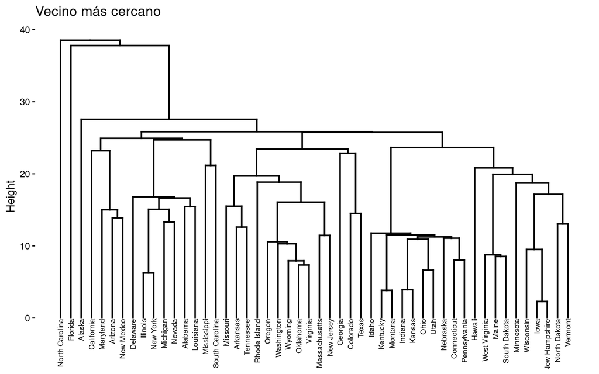

```r
d_arrests <- dist(USArrests)

fviz_dend(hclust(d_arrests, method = "single"), main = "Vecino más cercano", cex = 0.5)
```

**Mostrar código**

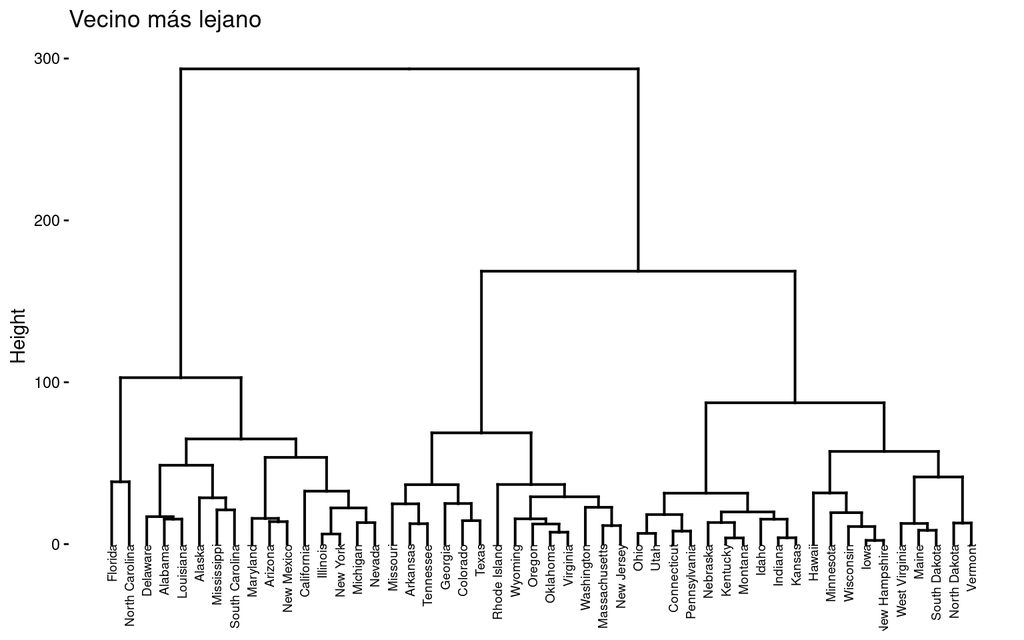

```r
fviz_dend(hclust(d_arrests, method = "complete"), main = "Vecino más lejano", cex = 0.5)
```

**Mostrar código**

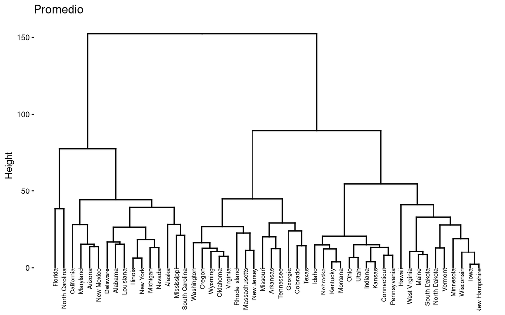

```r
fviz_dend(hclust(d_arrests, method = "average"), main = "Promedio", cex = 0.5)
```

**Mostrar código**

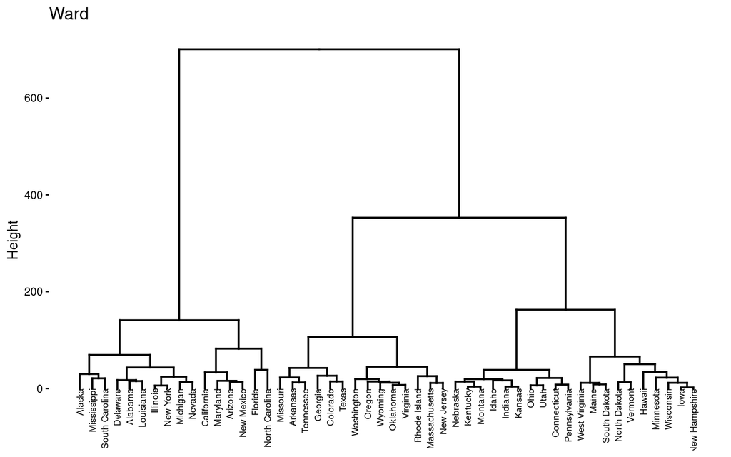

```r
fviz_dend(hclust(d_arrests, method = "ward.D2"), main = "Ward", cex = 0.5)
```

El vecino más cercano tiende a producir cadenas de fusiones sucesivas (efecto *chaining*): un estado se suma de a uno a un grupo grande, en vez de formarse grupos compactos. Ward, en cambio, tiende a producir grupos de tamaño más parejo.

## 5.3 Coeficiente de correlación cofenético

Un dendrograma impone una estructura sobre los datos que no necesariamente respeta las distancias originales. La **matriz cofenética** contiene, para cada par de observaciones, la distancia a la que quedaron unidas en el dendrograma. El coeficiente de correlación cofenético, la correlación entre esas distancias y las originales, mide qué tan fiel es esa representación: cuanto más alto, menos distorsión introduce el método.

**Mostrar código**

```r
tibble(
  metodo = c("single", "complete", "average", "centroid", "ward.D2"),
  cor_cofenetica = map_dbl(metodo, \(m) cor(d_arrests, cophenetic(hclust(d_arrests, method = m))))
) |>
  arrange(desc(cor_cofenetica))
```

| metodo | cor_cofenetica |
| --- | --- |
| average | 0.7658983 |
| centroid | 0.7642451 |
| complete | 0.7636926 |
| ward.D2 | 0.7609613 |
| single | 0.5702505 |

## 5.4 El efecto de estandarizar

**Mostrar código**

```r
d_sin_est <- dist(USArrests)
d_con_est <- dist(scale(USArrests))

grupos_sin_est <- cutree(hclust(d_sin_est, method = "ward.D2"), k = 4)
grupos_con_est <- cutree(hclust(d_con_est, method = "ward.D2"), k = 4)

table(sin_estandarizar = grupos_sin_est, con_estandarizar = grupos_con_est)
```

```
                con_estandarizar
sin_estandarizar  1  2  3  4
               1  5 10  1  0
               2  2  2 10  0
               3  0  0  7  3
               4  0  0  1  9
```

**Mostrar código**

```r
adjustedRandIndex(grupos_sin_est, grupos_con_est)
```

```
[1] 0.3537682
```

Las dos particiones distan bastante de coincidir (un índice de Rand ajustado de alrededor de 0.35, lejos del 1 que indicaría particiones idénticas). De acá en más trabajamos siempre con los datos estandarizados.

**Mostrar código**

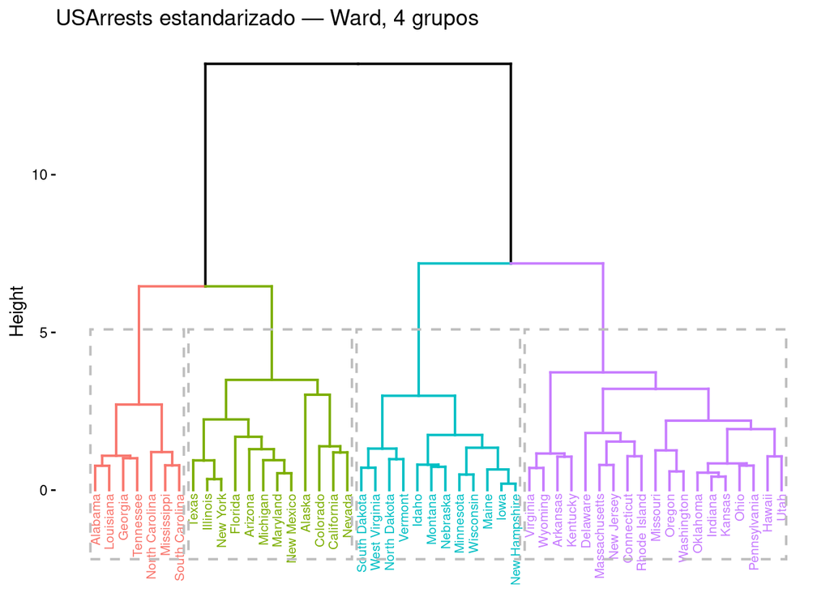

```r
hc_arrests <- hclust(d_con_est, method = "ward.D2")

fviz_dend(hc_arrests, k = 4, rect = TRUE, cex = 0.55,
          main = "USArrests estandarizado — Ward, 4 grupos")
```

# 6 Selección del número de conglomerados

¿Cuántos grupos conviene retener? Hay tres criterios usuales, todos construidos sobre la descomposición $\textbf{T}=\textbf{W}+\textbf{B}$ de la sección 3: comparan variabilidad dentro de los grupos con variabilidad total o entre grupos.

Necesitamos primero la suma de cuadrados dentro (SCD) para una cantidad de grupos dada. Se escribe **una función**, en vez de repetir el cálculo para cada valor de $k$:

**Mostrar código**

```r
scd_total <- function(datos, grupos) {
  datos |>
    as.data.frame() |>
    split(grupos) |>
    map_dbl(\(g) if (nrow(g) > 1) sum(diag(var(g))) * (nrow(g) - 1) else 0) |>
    sum()
}

scd_por_k <- tibble(
  k   = 2:10,
  scd = map_dbl(k, \(k) scd_total(scale(USArrests), cutree(hc_arrests, k = k)))
)

scd_por_k
```

| k | scd |
| --- | --- |
| 2 | 104.65560 |
| 3 | 78.82056 |
| 4 | 57.94270 |
| 5 | 50.97090 |
| 6 | 44.85972 |
| 7 | 39.70538 |
| 8 | 35.12999 |
| 9 | 30.65010 |
| 10 | 26.96570 |

**Mostrar código**

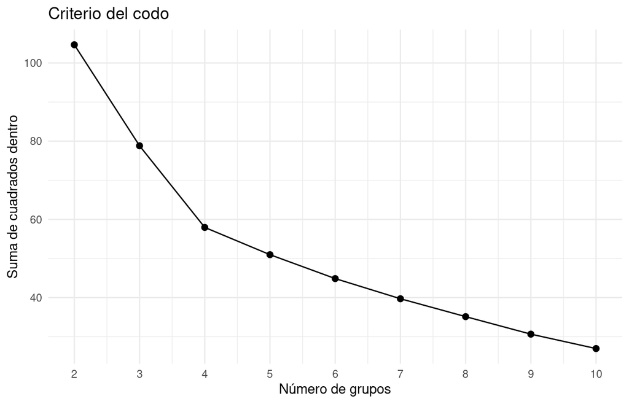

```r
scd_por_k |>
  ggplot(aes(k, scd)) +
  geom_line() +
  geom_point(size = 2) +
  scale_x_continuous(breaks = scd_por_k$k) +
  labs(title = "Criterio del codo", x = "Número de grupos", y = "Suma de cuadrados dentro")
```

La SCD baja siempre que se agregan grupos (en el extremo, con $k=n$ es cero), así que no se busca un mínimo sino el punto donde la curva deja de caer con fuerza: el “codo”. Acá el descenso se frena de forma visible alrededor de $k=4$, coherente con lo que sugieren los criterios siguientes.

## 6.1 F de Hartigan

$$F = \frac{\textbf{W}_g - \textbf{W}_{g+1}}{\textbf{W}_{g+1}/(n-g-1)}$$

Hartigan (1975) sugiere agregar un grupo más si $F>10$: una ganancia grande en homogeneidad justifica la partición adicional.

**Mostrar código**

```r
n <- nrow(USArrests)

hartigan <- tibble(
  de = scd_por_k$k[-nrow(scd_por_k)],
  a  = scd_por_k$k[-1],
  F  = (scd_por_k$scd[-nrow(scd_por_k)] - scd_por_k$scd[-1]) /
       (scd_por_k$scd[-1] / (n - scd_por_k$k[-nrow(scd_por_k)] - 1))
)

hartigan
```

| de | a | F |
| --- | --- | --- |
| 2 | 3 | 15.405200 |
| 3 | 4 | 16.574675 |
| 4 | 5 | 6.155109 |
| 5 | 6 | 5.994058 |
| 6 | 7 | 5.582031 |
| 7 | 8 | 5.470144 |
| 8 | 9 | 5.992655 |
| 9 | 10 | 5.465317 |

**Mostrar código**

```r
# La regla es secuencial: se parte de g=2 y se suma un grupo mientras F > 10;
# el número de grupos sugerido es el primer g en el que la condición falla
# (no el mayor g con F > 10, que asume sin comprobarlo que F es monótona)
primera_falla <- hartigan |> filter(F <= 10) |> slice(1)
k_hartigan <- if (nrow(primera_falla) > 0) primera_falla$de else max(hartigan$a)

cat(glue::glue(
  "Siguiendo la regla de Hartigan (agregar un grupo mientras F > 10), ",
  "el criterio sugiere **{k_hartigan} grupos**: el paso de {k_hartigan - 1} a {k_hartigan} ",
  "todavía supera el umbral, mientras que el paso de {k_hartigan} a {k_hartigan + 1} ya no lo hace."
))
```

Siguiendo la regla de Hartigan (agregar un grupo mientras F > 10), el criterio sugiere **4 grupos**: el paso de 3 a 4 todavía supera el umbral, mientras que el paso de 4 a 5 ya no lo hace.

## 6.2 Calinski y Harabasz

$$CH(g) = \frac{\text{traza}(\textbf{B})}{\text{traza}(\textbf{W})}\cdot\frac{n-g}{g-1}$$

A diferencia del $F$ de Hartigan, no compara $g$ contra $g+1$: da un puntaje por cada $g$, y se busca el que lo maximiza.

**Mostrar código**

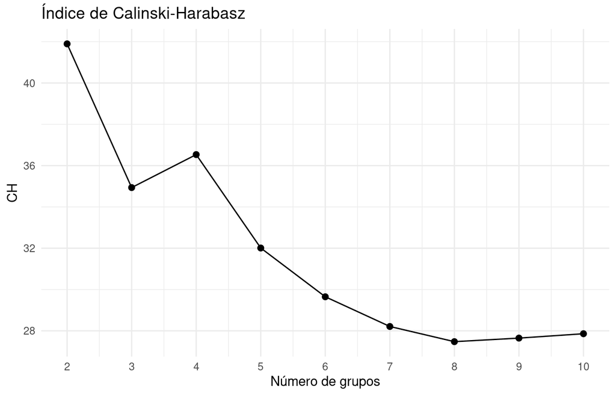

```r
ch <- tibble(
  k  = 2:10,
  CH = map_dbl(k, \(k) calinhara(scale(USArrests), cutree(hc_arrests, k = k)))
)

ch |>
  ggplot(aes(k, CH)) +
  geom_line() +
  geom_point(size = 2) +
  scale_x_continuous(breaks = 2:10) +
  labs(title = "Índice de Calinski-Harabasz", x = "Número de grupos", y = "CH")
```

**Mostrar código**

```r
ch |> slice_max(CH, n = 1)
```

| k | CH |
| --- | --- |
| 2 | 41.89486 |

El máximo global está en $k=2$: separar los estados en “más” y “menos” violentos es, en términos de este índice, la partición más nítida. Hay, sin embargo, un máximo local en $k=4$, coherente con lo que sugirió Hartigan: dentro de la partición gruesa en dos grupos hay subestructura adicional que un CH global no necesariamente resalta.

## 6.3 Coeficiente de silueta

Para la observación $i$, la silueta compara la disimilitud promedio con su propio grupo ($a_i$) contra la disimilitud promedio con el grupo más cercano ($b_i$):

$$s_i = \frac{b_i-a_i}{\max(a_i,b_i)}, \qquad SC = \frac{1}{n}\sum_{i=1}^n s_i$$

Valores de $SC$ cercanos a 1 indican estructura fuerte; Rousseeuw (1987) propone $SC\geq 0.71$ como estructura fuerte, $0.51$–$0.70$ razonable, $0.26$–$0.50$ débil, y por debajo de $0.26$, sin estructura sustancial.

**Mostrar código**

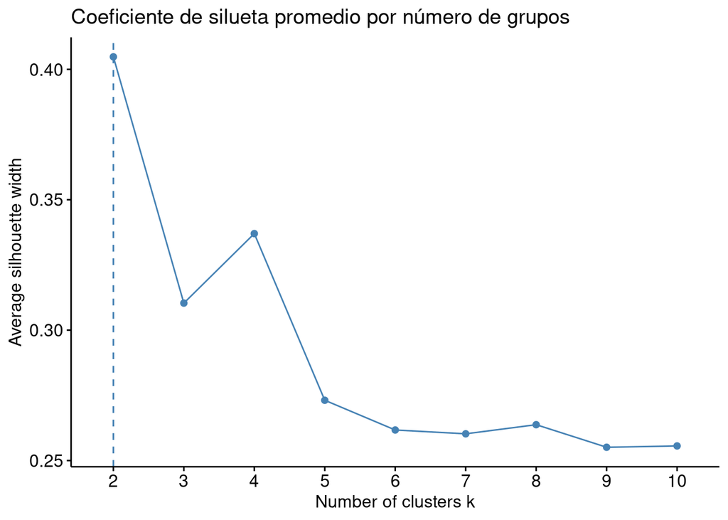

```r
silueta <- tibble(
  k  = 2:10,
  SC = map_dbl(k, \(k) mean(silhouette(cutree(hc_arrests, k = k), d_con_est)[, 3]))
)

fviz_nbclust(scale(USArrests), FUNcluster = hcut, method = "silhouette", k.max = 10) +
  labs(title = "Coeficiente de silueta promedio por número de grupos")
```

**Mostrar código**

```r
silueta |> slice_max(SC, n = 1)
```

| k | SC |
| --- | --- |
| 2 | 0.4047945 |

El promedio $SC$ resume en un solo número lo que en realidad varía observación por observación: conviene mirar la silueta de cada estado por separado, no solo el promedio.

**Mostrar código**

```
  cluster size ave.sil.width
1       1    7          0.46
2       2   12          0.29
3       3   19          0.26
4       4   12          0.43
```

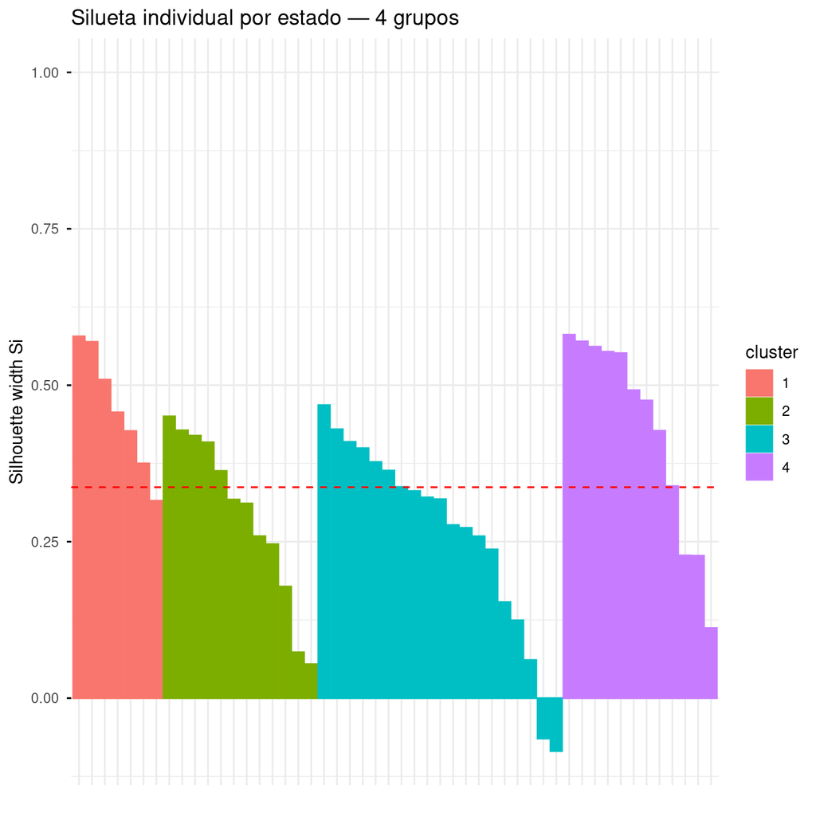

```r
grupos4 <- cutree(hc_arrests, k = 4)
sil4    <- silhouette(grupos4, d_con_est)
rownames(sil4) <- rownames(USArrests)

fviz_silhouette(sil4) +
  labs(title = "Silueta individual por estado — 4 grupos")
```

**Mostrar código**

```r
sil4_df <- as_tibble(sil4[, 1:3], rownames = "estado") |>
  arrange(sil_width)

sil4_df |> filter(sil_width < 0)
```

| estado | cluster | neighbor | sil_width |
| --- | --- | --- | --- |
| Arkansas | 3 | 1 | -0.08467352 |
| Kentucky | 3 | 4 | -0.06459230 |

**Mostrar código**

```r
estados_negativos <- sil4_df |> filter(sil_width < 0) |> pull(estado)

lista_estados <- glue::glue_collapse(glue::glue("**{estados_negativos}**"), sep = ", ", last = " y ")
verbo <- if (length(estados_negativos) == 1) "queda" else "quedan"

if (length(estados_negativos) > 0) {
  cat(glue::glue(
    "Casi todas las siluetas son positivas, pero unos pocos estados quedan con ",
    "$s_i$ cercano a cero o negativo: son los que están en el borde entre dos ",
    "grupos, más parecidos al grupo vecino que al propio. En esta partición ",
    "{lista_estados} {verbo} con $s_i<0$: `hclust()` los asigna a un grupo, pero ",
    "su distancia al grupo vecino es, en promedio, menor que la distancia dentro ",
    "del propio grupo. No es un error del algoritmo (cada observación tiene que ",
    "ir a algún grupo), sino una señal de que, para esos estados en particular, ",
    "la frontera entre grupos no está bien definida."
  ))
} else {
  cat(glue::glue(
    "En esta partición todas las siluetas son positivas: no hay estados en el ",
    "borde entre dos grupos, más parecidos al grupo vecino que al propio."
  ))
}
```

Casi todas las siluetas son positivas, pero unos pocos estados quedan con $s_i$ cercano a cero o negativo: son los que están en el borde entre dos grupos, más parecidos al grupo vecino que al propio. En esta partición **Arkansas** y **Kentucky** quedan con $s_i<0$: `hclust()` los asigna a un grupo, pero su distancia al grupo vecino es, en promedio, menor que la distancia dentro del propio grupo. No es un error del algoritmo (cada observación tiene que ir a algún grupo), sino una señal de que, para esos estados en particular, la frontera entre grupos no está bien definida.

# 7 Descripción de los grupos

Una vez fijado el número de grupos, conviene caracterizarlos: qué variables distinguen a cada uno de la media general. Se usa un estadístico $t$ que compara la media del grupo $g$ en la variable $j$ contra la media general:

$$t_j = \frac{\bar{x}_{jg}-\bar{x}_j}{\sqrt{\frac{s_{jj}}{n_g}\cdot\frac{n-n_g}{n-1}}}$$

Se calcula **una vez, con una función**, y se aplica a cada grupo con `map()`.

**Mostrar código**

```r
media_general <- colMeans(USArrests)
var_general   <- diag(var(USArrests))

describir_grupo <- function(g) {
  datos_g <- USArrests[grupos4 == g, ]
  n_g     <- nrow(datos_g)
  media_g <- colMeans(datos_g)

  error_est <- sqrt((var_general / n_g) * ((n - n_g) / (n - 1)))
  t_stat    <- (media_g - media_general) / error_est
  p_val     <- 2 * pt(abs(t_stat), df = n_g - 1, lower.tail = FALSE)

  tibble(variable = names(t_stat), media_grupo = media_g, t = t_stat, p_valor = p_val)
}

descripcion <- map(1:4, describir_grupo) |>
  set_names(paste0("Grupo ", 1:4, " (n=", table(grupos4), ")"))

descripcion
```

```
$`Grupo 1 (n=7)`
# A tibble: 4 × 4
  variable media_grupo      t p_valor
  <chr>          <dbl>  <dbl>   <dbl>
1 Murder          14.7  4.46  0.00427
2 Assault        251.   2.73  0.0342
3 UrbanPop        54.3 -2.20  0.0705
4 Rape            21.7  0.137 0.896

$`Grupo 2 (n=12)`
# A tibble: 4 × 4
  variable media_grupo     t  p_valor
  <chr>          <dbl> <dbl>    <dbl>
1 Murder          11.0  2.87 0.0152
2 Assault        264    4.40 0.00106
3 UrbanPop        76.5  2.98 0.0126
4 Rape            33.6  5.20 0.000295

$`Grupo 3 (n=19)`
# A tibble: 4 × 4
  variable media_grupo     t p_valor
  <chr>          <dbl> <dbl>   <dbl>
1 Murder          6.21 -1.98  0.0626
2 Assault       142.   -1.89  0.0753
3 UrbanPop       71.3   2.17  0.0439
4 Rape           19.2  -1.20  0.246

$`Grupo 4 (n=12)`
# A tibble: 4 × 4
  variable media_grupo     t  p_valor
  <chr>          <dbl> <dbl>    <dbl>
1 Murder          3.09 -4.24 0.00139
2 Assault        76    -4.47 0.000943
3 UrbanPop       52.1  -3.66 0.00377
4 Rape           11.8  -3.95 0.00228
```

# 8 K-medias

Los métodos jerárquicos construyen una secuencia completa de particiones anidadas. K-medias, en cambio, busca directamente una única partición en $k$ grupos, fijado de antemano, minimizando la suma de cuadrados dentro de los grupos ($\textbf{W}$). El algoritmo:

1. Elige $k$ centroides iniciales.
2. Asigna cada observación al centroide más cercano.
3. Recalcula los centroides con las observaciones ya asignadas.
4. Repite 2–3 hasta que las asignaciones no cambian (o se llega al máximo de iteraciones).

**Mostrar código**

```r
set.seed(123)
km_arrests <- kmeans(scale(USArrests), centers = 4, nstart = 25)

km_arrests$size
```

```
[1]  8 13 16 13
```

**Mostrar código**

```r
km_arrests$centers
```

```
      Murder    Assault   UrbanPop        Rape
1  1.4118898  0.8743346 -0.8145211  0.01927104
2 -0.9615407 -1.1066010 -0.9301069 -0.96676331
3 -0.4894375 -0.3826001  0.5758298 -0.26165379
4  0.6950701  1.0394414  0.7226370  1.27693964
```

**Mostrar código**

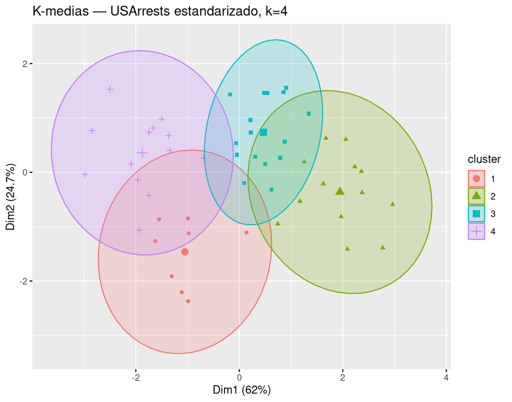

```r
fviz_cluster(km_arrests, data = scale(USArrests), geom = "point",
             ellipse.type = "norm", main = "K-medias — USArrests estandarizado, k=4")
```

## 8.1 Estabilidad: por qué importa `nstart`

Como el algoritmo depende de los centroides iniciales, semillas distintas pueden terminar en óptimos locales distintos. `nstart` corre el algoritmo varias veces desde puntos de partida distintos y se queda con el mejor resultado (menor $\textbf{W}$ total):

**Mostrar código**

```r
comparar_nstart <- function(nstart, semilla) {
  set.seed(semilla)
  kmeans(scale(USArrests), centers = 4, nstart = nstart)$tot.withinss
}

tibble(semilla = 1:10) |>
  mutate(
    nstart_1  = map_dbl(semilla, \(s) comparar_nstart(1, s)),
    nstart_25 = map_dbl(semilla, \(s) comparar_nstart(25, s))
  )
```

| semilla | nstart_1 | nstart_25 |
| --- | --- | --- |
| 1 | 69.86858 | 56.40317 |
| 2 | 56.40317 | 56.40317 |
| 3 | 56.40317 | 56.40317 |
| 4 | 69.86858 | 56.40317 |
| 5 | 56.40317 | 56.40317 |
| 6 | 69.66691 | 56.40317 |
| 7 | 56.40317 | 56.40317 |
| 8 | 69.66691 | 56.40317 |
| 9 | 56.40317 | 56.40317 |
| 10 | 56.40317 | 56.40317 |

Con `nstart = 1`, el resultado final cambia según la semilla; con `nstart = 25`, siempre converge al mismo valor. Por eso conviene usar `nstart` alto (25 o más) en la práctica.

## 8.2 K-medias contra el agrupamiento jerárquico

**Mostrar código**

```r
adjustedRandIndex(km_arrests$cluster, grupos4)
```

```
[1] 0.8244826
```

Un índice de Rand ajustado alto (bien por encima de 0) indica que ambos métodos, aunque parten de lógicas distintas, coinciden en gran medida sobre cómo agrupar los estados.

# 9 Validación con grupos conocidos

`USArrests` no tiene una partición “verdadera” contra la cual comparar. `penguins` sí: la especie de cada pingüino es un dato observado, no algo que el algoritmo tenga que adivinar. Agrupamos ignorando `species` y preguntamos si los conglomerados la recuperan.

**Mostrar código**

```r
penguins_num <- penguins |>
  select(bill_length_mm, bill_depth_mm, flipper_length_mm, body_mass_g)

penguins_num_std <- scale(penguins_num)
```

**Mostrar código**

```r
hc_penguins <- hclust(dist(penguins_num_std), method = "ward.D2")
grupos_penguins <- cutree(hc_penguins, k = 3)

table(especie_real = penguins$species, conglomerado = grupos_penguins)
```

```
            conglomerado
especie_real   1   2   3
   Adelie    146   0   0
   Chinstrap  11   0  57
   Gentoo      0 119   0
```

**Mostrar código**

```r
ari_jerarquico <- adjustedRandIndex(grupos_penguins, penguins$species)
ari_jerarquico
```

```
[1] 0.9132404
```

Se compara además con k-medias:

**Mostrar código**

```r
set.seed(123)
km_penguins <- kmeans(penguins_num_std, centers = 3, nstart = 25)

table(especie_real = penguins$species, conglomerado = km_penguins$cluster)
```

```
            conglomerado
especie_real   1   2   3
   Adelie     22 124   0
   Chinstrap  63   5   0
   Gentoo      0   0 119
```

**Mostrar código**

```r
ari_kmedias <- adjustedRandIndex(km_penguins$cluster, penguins$species)
ari_kmedias
```

```
[1] 0.799421
```

**Mostrar código**

```r
mejor <- if (ari_jerarquico > ari_kmedias) "el agrupamiento jerárquico" else "k-medias"

cat(glue::glue(
  "El índice de Rand ajustado es **{round(ari_jerarquico, 2)}** para el agrupamiento jerárquico ",
  "y **{round(ari_kmedias, 2)}** para k-medias: ambos recuperan la estructura de especies ",
  "razonablemente bien (contra un valor esperado de 0 si la asignación fuera al azar), ",
  "y en este caso {mejor} se ajusta algo mejor a las especies reales. ",
  "La confusión, cuando ocurre, es sobre todo entre Adelie y Chinstrap: son las dos especies ",
  "más parecidas en las variables morfológicas usadas."
))
```

El índice de Rand ajustado es **0.91** para el agrupamiento jerárquico y **0.8** para k-medias: ambos recuperan la estructura de especies razonablemente bien (contra un valor esperado de 0 si la asignación fuera al azar), y en este caso el agrupamiento jerárquico se ajusta algo mejor a las especies reales. La confusión, cuando ocurre, es sobre todo entre Adelie y Chinstrap: son las dos especies más parecidas en las variables morfológicas usadas.

**Mostrar código**

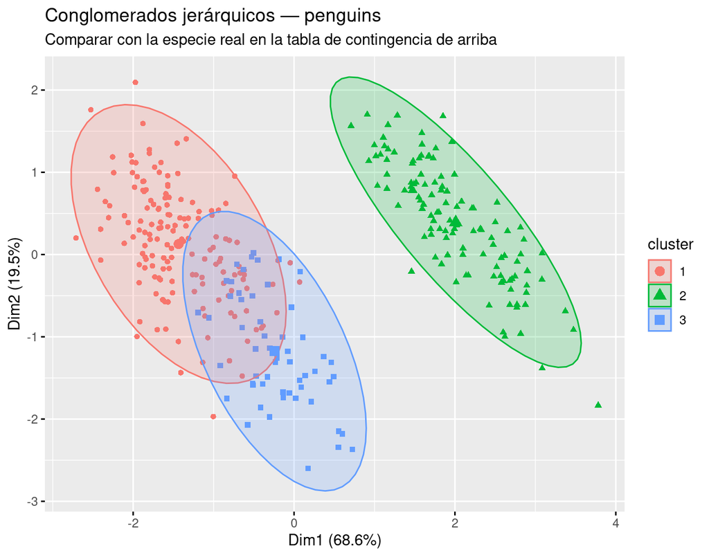

```r
fviz_cluster(list(data = penguins_num_std, cluster = grupos_penguins), geom = "point",
             ellipse.type = "norm", main = "Conglomerados jerárquicos — penguins") +
  labs(subtitle = "Comparar con la especie real en la tabla de contingencia de arriba")
```

# 10 Comparación de métodos de agrupamiento

`clValid` compara sistemáticamente varios métodos y números de grupos con dos familias de medidas:

**Medidas internas** (no necesitan una partición de referencia):

- **Conectividad**: grado en que observaciones cercanas quedan en el mismo grupo, según sus vecinos más próximos. Va de 0 a infinito; se minimiza.
- **Silueta** (Silhouette Width): la vista en la sección anterior, promediada; se maximiza.
- **Dunn**: cociente entre la menor distancia entre grupos distintos y la mayor distancia dentro de un grupo. Va de 0 a infinito; se maximiza.

**Medidas de estabilidad** (comparan el agrupamiento original contra el que resulta de eliminar, de a una, cada columna; todas se minimizan):

- **APN** (*Average Proportion of Non-overlap*): proporción promedio de observaciones que cambian de grupo al eliminar una columna.
- **AD** (*Average Distance*): distancia promedio entre observaciones que permanecen en el mismo grupo en ambos casos.
- **ADM** (*Average Distance between Means*): distancia promedio entre los centros de los grupos, para esas mismas observaciones.
- **FOM** (*Figure of Merit*): varianza intra-grupo promedio de la columna eliminada, agrupando con las columnas restantes.

**Mostrar código**

```r
comparacion <- clValid(
  obj        = scale(USArrests),
  nClust     = 2:6,
  clMethods  = c("hierarchical", "kmeans", "pam"),
  validation = c("internal", "stability")
)

summary(comparacion)
```

```
Clustering Methods:
 hierarchical kmeans pam

Cluster sizes:
 2 3 4 5 6

Validation Measures:
                                 2       3       4       5       6

hierarchical APN            0.0853  0.1456  0.1608  0.2239  0.2740
             AD             1.9637  1.9212  1.7373  1.5406  1.4999
             ADM            0.3079  0.4509  0.4828  0.5832  0.6971
             FOM            0.8252  0.8199  0.7740  0.7121  0.7106
             Connectivity   6.6437  9.5615 13.9563 22.5782 31.2873
             Dunn           0.2214  0.2214  0.2224  0.2046  0.2126
             Silhouette     0.4085  0.3486  0.3637  0.3213  0.2720
kmeans       APN            0.0533  0.1820  0.3607  0.2077  0.2393
             AD             1.8891  1.8127  1.7144  1.4311  1.3715
             ADM            0.1652  0.5492  0.7949  0.4357  0.4934
             FOM            0.7506  0.8057  0.6895  0.6534  0.6877
             Connectivity   6.6437 13.6484 16.2413 24.6639 33.7194
             Dunn           0.2214  0.2224  0.2224  0.1983  0.2231
             Silhouette     0.4085  0.3668  0.3573  0.3377  0.3079
pam          APN            0.0660  0.1562  0.2077  0.1824  0.2107
             AD             1.9079  1.7200  1.5515  1.4132  1.3384
             ADM            0.2207  0.4066  0.5123  0.4249  0.4213
             FOM            0.7795  0.7569  0.7099  0.6731  0.6680
             Connectivity   6.6437 13.8302 20.4421 29.5726 38.2643
             Dunn           0.2214  0.1376  0.1849  0.1849  0.2019
             Silhouette     0.4085  0.3144  0.3390  0.3105  0.2630

Optimal Scores:

             Score  Method       Clusters
APN          0.0533 kmeans       2
AD           1.3384 pam          6
ADM          0.1652 kmeans       2
FOM          0.6534 kmeans       5
Connectivity 6.6437 hierarchical 2
Dunn         0.2231 kmeans       6
Silhouette   0.4085 hierarchical 2
```

Ningún método domina en todas las medidas a la vez (es habitual que no lo haga), pero da un panorama más completo que mirar un solo criterio: por ejemplo, si la silueta y la conectividad coinciden en preferir el mismo método y número de grupos, es una señal más fuerte que cualquiera de las dos por separado.

# 11 Otros algoritmos

Estos algoritmos **no forman parte de la evaluación de la materia**. Se mencionan brevemente, sin desarrollo completo.

## 11.1 K-medias recortado

K-medias es sensible a valores atípicos: una observación extrema puede desplazar apreciablemente un centroide. El algoritmo recortado (Kondo, 2011) itera k-medias ignorando, en cada paso, el $\alpha\%$ de observaciones más alejadas de sus centros.

**Mostrar código**

```r
rskc <- RSKC::RSKC(scale(USArrests), ncl = 4, alpha = 0.1)

table(rskc$labels)
```

```
 1  2  3  4
12 19  7 12
```

**Mostrar código**

```r
rownames(USArrests)[rskc$oW]   # observaciones tratadas como atípicas y excluidas
```

```
[1] "Alaska"         "Arkansas"       "Kentucky"       "North Carolina"
[5] "Rhode Island"
```

## 11.2 K-modas

Extensión de k-medias para variables categóricas (Huang, 1997): en vez de centroides (medias), usa modas, y la disimilitud es la cantidad de atributos en los que dos observaciones difieren.

**Mostrar código**

```r
set.seed(1)
categoricas_penguins <- penguins |>
  transmute(island = factor(island), sex = factor(sex)) |>
  as.data.frame()   # kmodes() indexa con data[, j]: no funciona sobre un tibble
kmodas <- klaR::kmodes(categoricas_penguins, modes = 3)

table(especie = penguins$species, conglomerado = kmodas$cluster)
```

```
           conglomerado
especie      1  2  3
  Adelie    50 35 61
  Chinstrap 49  0 19
  Gentoo     0 61 58
```

## 11.3 K-prototipos

Combina k-medias y k-modas para datos mixtos: la distancia entre dos observaciones suma una parte euclídea (variables numéricas) y una parte de coincidencia simple ponderada por $\gamma$ (variables categóricas).

**Mostrar código**

```r
mixtas_penguins <- penguins |>
  transmute(bill_length_mm, bill_depth_mm, flipper_length_mm, body_mass_g,
            island = factor(island), sex = factor(sex))

set.seed(1)
kproto <- clustMixType::kproto(mixtas_penguins, k = 3, verbose = FALSE)

table(especie = penguins$species, conglomerado = kproto$cluster)
```

```
           conglomerado
especie       1   2   3
  Adelie     63   5  78
  Chinstrap  30   1  37
  Gentoo     14 104   1
```

## 11.4 Mapas auto-organizativos

Los mapas auto-organizativos (*SOM*, Kohonen) son redes neuronales no supervisadas que proyectan los datos sobre una grilla de neuronas, de forma que neuronas vecinas en la grilla representan observaciones parecidas. Quedan fuera del alcance de este práctico; el paquete de referencia en R es `kohonen`.

# 12 Referencias

- Aldás, J. y Uriel, E. (2017). *Análisis multivariante aplicado con R*. Paraninfo.
- Everitt, B. S., Landau, S., Leese, M. y Stahl, D. (2011). *Cluster Analysis* (5ta ed.). Wiley.
- Hartigan, J. A. (1975). *Clustering Algorithms*. Wiley.
- Calinski, T. y Harabasz, J. (1974). A dendrite method for cluster analysis. *Communications in Statistics*, 3(1), 1–27.
- Rousseeuw, P. J. (1987). Silhouettes: a graphical aid to the interpretation and validation of cluster analysis. *Journal of Computational and Applied Mathematics*, 20, 53–65.
- Murtagh, F. y Legendre, P. (2014). Ward’s hierarchical agglomerative clustering method: which algorithms implement Ward’s criterion? *Journal of Classification*, 31, 274–295.
- Huang, Z. (1997). A fast clustering algorithm to cluster very large categorical data sets in data mining. En *KDD: Techniques and Applications*.
- Huang, Z. (1998). Extensions to the k-means algorithm for clustering large data sets with categorical values. *Data Mining and Knowledge Discovery*, 2, 283–304.
- Kondo, Y. (2011). *Robustification of the sparse K-means clustering algorithm*. Tesis de maestría, University of British Columbia.
- Johnson, R. A. y Wichern, D. W. (2007). *Applied Multivariate Statistical Analysis* (6ta ed.). Pearson.
- Peña, D. (2002). *Análisis de Datos Multivariantes*. McGraw-Hill.